title: “MAM11 Prediction Models Notebook, Joost Wagemans & Chi Him Ng” output: html_notebook —

In this assignment we will develop and evaluate prediction models for breast cancer. The dataset is provided in the package “mlbench” so you do not need to download it from an explicit address.

What should you submit? You need to submit: 1. This Notebook (in .Rmd format) after filling in all your answers inside this notebook. You are required to do an action (write or fill-in code or write documentation) at the places marked by an arrow (=>). This arrow appears either in the comments (and it will be preceeded by “#”) or outside the text (without “#”). One of the actions is to document a chunk of code. Inside the code you need to document the commands marked with “#@”. 2. The Notebook in html format with all the results.

Grading: The practical has two parts. The first is a “closed” part, in which you are expected to add some code or to document a chunk of code. The other part is open, in which you choose a non-parametric approach to learn models, and you compare a strategy based on this new approach to a strategy that you learn during the closed part. The closed part amounts to 70% of the grade and the open part amounts to 30% of the grade. Of course we are more than happy to help you (also) on the open part but it is emphatically intended to be your own work.

Good luck!

==> Student Name(s): Joost Wagemans Chi Him Ng ==> Student number(s): 11688092, 12389986

Load libraries

Set options

# read file

```r
data(BreastCancer, package="mlbench")
names(BreastCancer) # * What are the names of the data frame bc?
```

```
##  [1] "Id"              "Cl.thickness"    "Cell.size"       "Cell.shape"
##  [5] "Marg.adhesion"   "Epith.c.size"    "Bare.nuclei"     "Bl.cromatin"
##  [9] "Normal.nucleoli" "Mitoses"         "Class"
```

```r
nrow(BreastCancer)  # * How many obseravtion (rows) are there?
```

```
## [1] 699
```

```r
# Take a moment to look at the description of the database on http://ugrad.stat.ubc.ca/R/library/mlbench/html/BreastCancer.html

# Print the dataset
BreastCancer
```

[output not shown]

[output cut: 1385 more lines]

```r
summary(BreastCancer)
```

```
##       Id             Cl.thickness   Cell.size     Cell.shape  Marg.adhesion
##  Length:699         1      :145   1      :384   1      :353   1      :407
##  Class :character   5      :130   10     : 67   2      : 59   2      : 58
##  Mode  :character   3      :108   3      : 52   10     : 58   3      : 58
##                     4      : 80   2      : 45   3      : 56   10     : 55
##                     10     : 69   4      : 40   4      : 44   4      : 33
##                     2      : 50   5      : 30   5      : 34   8      : 25
##                     (Other):117   (Other): 81   (Other): 95   (Other): 63
##   Epith.c.size  Bare.nuclei   Bl.cromatin  Normal.nucleoli    Mitoses
##  2      :386   1      :402   2      :166   1      :443     1      :579
##  3      : 72   10     :132   3      :165   10     : 61     2      : 35
##  4      : 48   2      : 30   1      :152   3      : 44     3      : 33
##  1      : 47   5      : 30   7      : 73   2      : 36     10     : 14
##  6      : 41   3      : 28   4      : 40   8      : 24     4      : 12
##  5      : 39   (Other): 61   5      : 34   6      : 22     7      :  9
##  (Other): 66   NA's   : 16   (Other): 69   (Other): 69     (Other): 17
##        Class
##  benign   :458
##  malignant:241
##
##
##
##
##
```

```r
sum(is.na(BreastCancer$Bare.nuclei)) ## There are 16 missing values in the Bare.nuclei column.
```

```
## [1] 16
```

```r
# => Are there any missing values? There are 16 missing values in the Bare.nuclei column.
# => Write the code to calculate the number of missing values in each column. You can use whatever suits you. For example you can use "sapply" on BreastCancer to work on all columns while using the is.na function, or (preferably) you can use the power of dplyr commands like "summarise" together with sum and "is.na".
#
#
```

Preprocess

```r
# => We will use only complete cases without any missing values in this excercise. Obtain the data frame "bc" with complete cases. Hint: look at the function complete.cases(). You can use it for example with the filter command of dplyr (or just use base R)
bc <- subset(BreastCancer, is.na(Bare.nuclei) == F)  # dataset with complete cases
# => How many obseravtion (rows) are there now?
# There are now 683 observations, because the 16 rows with missin g values in Bare.nuclei where deleted.

# How many cases did we remove?
# 16

# remove id column
bc <- subset(bc, select = -1) #=> Remove the "id" column from bc. Note that if you consider to use the "select" command in dplyr then this command may clash with the select command in the MASS library. Therefore use dplyr::select in that case.

# => convert the first 9 factors to numeric. You can use a for loop on these variables, or use "mutate_at".
bc$Cl.thickness <- as.numeric(bc$Cl.thickness)
bc$Cell.size <- as.numeric(bc$Cell.size)
bc$Cell.shape <- as.numeric(bc$Cell.shape)
bc$Marg.adhesion <- as.numeric(bc$Marg.adhesion)
bc$Epith.c.size <- as.numeric(bc$Epith.c.size)
bc$Bare.nuclei <-  as.numeric(bc$Bare.nuclei)
bc$Bl.cromatin <- as.numeric(bc$Bl.cromatin)
bc$Normal.nucleoli <- as.numeric(bc$Normal.nucleoli)
bc$Mitoses <- as.numeric(bc$Mitoses)

str(bc)
```

```
## 'data.frame':    683 obs. of  10 variables:
##  $ Cl.thickness   : num  5 5 3 6 4 8 1 2 2 4 ...
##  $ Cell.size      : num  1 4 1 8 1 10 1 1 1 2 ...
##  $ Cell.shape     : num  1 4 1 8 1 10 1 2 1 1 ...
##  $ Marg.adhesion  : num  1 5 1 1 3 8 1 1 1 1 ...
##  $ Epith.c.size   : num  2 7 2 3 2 7 2 2 2 2 ...
##  $ Bare.nuclei    : num  1 10 2 4 1 10 10 1 1 1 ...
##  $ Bl.cromatin    : num  3 3 3 3 3 9 3 3 1 2 ...
##  $ Normal.nucleoli: num  1 2 1 7 1 7 1 1 1 1 ...
##  $ Mitoses        : num  1 1 1 1 1 1 1 1 5 1 ...
##  $ Class          : Factor w/ 2 levels "benign","malignant": 1 1 1 1 1 2 1 1 1 1 ...
```

```r
# Look at the class variable
bc$Class
```

[output not shown]

[output cut: 84 more lines]

```r
# => change "malignant" into the number 1, and "bening" into the number 0. You can use a simple ifelse, or use the "recode" command in dplkr.
bc$Class <- ifelse(bc$Class == "malignant", 1, 0)
```

We will work with logistic regression models in this assignment to predict the probability of the malignant class (class = 1), but we could have used other kinds of models. We will fit two logistic regression models: one with only Mitoses as covariate, and another model with Mitoses and Cl.thickness. We will use the “lrm” command in the “rms” package but we could have also used the base R command “glm” instead. We will see later how to use glm.

```r
ddist <- datadist(bc) # preparation: in package rms we need to define the data distribution of the variables first. So before any models are fitted, this command stores the distribution summaries (e.g. ranges) for all potential variables.
options(datadist='ddist') # This means that when we fit a model we will also store the distribution information with the model object as well
mitoses.lrm <- lrm(Class~Mitoses, x=T, y=T, data=bc) # x = T and y=Y mean that the object mitoses.lrm will not only inlcude the model but will also keep the data as well. This is useful when we want access to the data via the model object.

summary(mitoses.lrm)
```

```
##              Effects              Response : Class
##
##  Factor      Low High Diff. Effect   S.E.   Lower 0.95 Upper 0.95
##  Mitoses     1   9    8        10.71 1.4311    7.905       13.515
##   Odds Ratio 1   9    8     44797.00     NA 2710.900   740260.000
```

```r
mitoses.thickness.lrm <- lrm(Class ~ Mitoses + Cl.thickness, x=T, y=T, data=bc) # fit a model that includes Mitoses and Cl.thickness as covariates
summary(mitoses.thickness.lrm)
```

```
##              Effects              Response : Class
##
##  Factor       Low High Diff. Effect    S.E.    Lower 0.95 Upper 0.95
##  Mitoses      1   9    8        6.9821 1.22330  4.5845        9.3797
##   Odds Ratio  1   9    8     1077.2000      NA 97.9510    11846.0000
##  Cl.thickness 2   6    4        3.6015 0.31442  2.9852        4.2178
##   Odds Ratio  2   6    4       36.6530      NA 19.7910       67.8810
```

What are the model’s characteristics on a test set? Let’s create a training and test sets and train the two models on the training set

```r
set.seed(1234) # we fix the seed so that results are the same for all students
train.smp.size <- round(0.7 * nrow(bc))
test.smp.size <- round(0.3 * nrow(bc))
####roandom columns
train.ind <- sample(seq_len(nrow(bc)), size = train.smp.size)

train <-  bc[train.ind, ] # => Obrain train set consisting of 70% of the data
test <-  bc[-train.ind, ] #=> Obtain test set consisting of the rest of observations


mitoses.train.lrm <- lrm(Class ~ Mitoses, x=T, y=T, data=train) # => fit lrm model on the training set using only Mitoses, use x=T and y=T
mitoses.thickness.train.lrm <- lrm(Class ~ Mitoses + Cl.thickness, x=T, y=T, data=train) # => fit lrm model on the training set using  Mitoses and Cl.thickness, use x=T and y=T
```

Now predict on the test set

```r
predicted.mitoses.test <- predict(mitoses.train.lrm, newdata = test, type = 'fitted') # => obtain the predicted probabilities of mitoses.train.lrm on the test set. Hint: use the "predict" function. Important note: make sure you use the right "type" in the command to get probabilities and not log odds.
predicted.mitoses.thickness.test <- predict(mitoses.thickness.train.lrm, test, type = "fitted") # => obtain the predicted probabilities of mitoses.thickness.train.lrm on the test set.Check that they indeed are between 0 and 1 and have no negative numbers etc.
```

Inspect histogram and ranges of probabilities

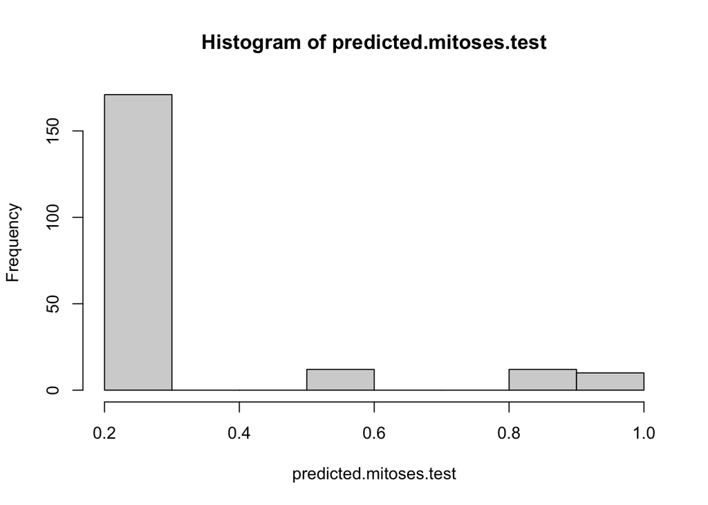

```r
 # => plot histogram of predicted.mitoses.test
hist(predicted.mitoses.test)
```

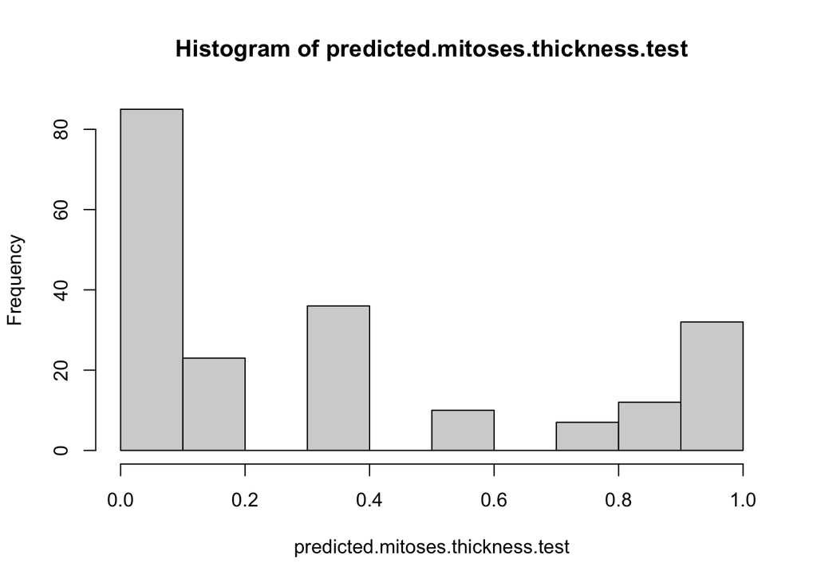

```r
 #* => plot histogram of predicted.mitoses.thickness.test
hist(predicted.mitoses.thickness.test)
```

```r
 #* => Obtain range of predicted.mitoses.test
summary(predicted.mitoses.test)
```

```
##    Min. 1st Qu.  Median    Mean 3rd Qu.    Max.
##  0.2627  0.2627  0.2627  0.3515  0.2627  1.0000
```

```r
 #* => Obtain range of predicted.mitoses.thickness.test
summary(predicted.mitoses.thickness.test)
```

```
##    Min. 1st Qu.  Median    Mean 3rd Qu.    Max.
## 0.01858 0.04140 0.18359 0.35242 0.53933 0.99995
```

Q: => From the point of view of larger range, which model is better? the model with mitoses and thickness had the biggest range, so this would be better